# Advanced Machine Learning - Easy Visa Problem Statement¶

### Problem Statement

With the help of classification model:

1. Facilitate the process of visa approvals
2. Recommend a suitable profile for the applicants for whom the visa should be certified or denied based on the drivers that significantly influence the case status

### Data Dictionary

The data contains the different attributes of employee and the employer. The detailed data dictionary is given below.

1. case_id: ID of each visa application
2. continent: Information of continent the employee
3. education_of_employee: Information of education of the employee
4. has_job_experience: Does the employee has any job experience? Y= Yes; N = No
5. requires_job_training: Does the employee require any job training? Y = Yes; N = No
6. no_of_employees: Number of employees in the employer's company
7. yr_of_estab: Year in which the employer's company was established
8. region_of_employment: Information of foreign worker's intended region of employment in the US.
9. prevailing_wage: Average wage paid to similarly employed workers in a specific occupation in the area of intended employment. The purpose of the prevailing wage is to ensure that the foreign worker is not underpaid compared to other workers offering the same or similar service in the same area of employment.
10. unit_of_wage: Unit of prevailing wage. Values include Hourly, Weekly, Monthly, and Yearly.
11. full_time_position: Is the position of work full-time? Y = Full Time Position; N = Part Time Position
12. case_status: Flag indicating if the Visa was certified or denied

The objective of this analysis is to find patterns within the dataset to gain further understanding of the data and leverage it to choose a machine learning algorithm that can recommend a suitable profile for the applicants whose visa should be certified or denied.

#### EDA

```python
#Import necessary libraries

import pandas as pd
import numpy as np
import seaborn as sns
import matplotlib.pyplot as plt

# Library to split data
from sklearn.model_selection import train_test_split

# To build model for prediction
from sklearn import tree
from sklearn.tree import DecisionTreeClassifier
from scipy.stats import randint, uniform
from sklearn.ensemble import(BaggingClassifier, RandomForestClassifier, AdaBoostClassifier,GradientBoostingClassifier)

#Hyperparameter tuning
from sklearn.model_selection import RandomizedSearchCV
from sklearn.model_selection import GridSearchCV

# To oversample and undersample data
import imblearn
from imblearn.over_sampling import SMOTE
from imblearn.under_sampling import RandomUnderSampler

# To get diferent metric scores
from sklearn.metrics import (f1_score, accuracy_score, recall_score, precision_score, confusion_matrix,make_scorer)
```

```python
from google.colab import drive
df = pd.read_csv('/content/drive/MyDrive/Colab Notebooks/EasyVisa.csv')
```

```python
# Make a copy of the dataset
df_temp = df.copy()
```

```python
#View a glimpse of the dataset

df.head()
```

|  | case_id | continent | education_of_employee | has_job_experience | requires_job_training | no_of_employees | yr_of_estab | region_of_employment | prevailing_wage | unit_of_wage | full_time_position | case_status |
| --- | --- | --- | --- | --- | --- | --- | --- | --- | --- | --- | --- | --- |
| 0 | EZYV01 | Asia | High School | N | N | 14513 | 2007 | West | 592.2029 | Hour | Y | Denied |
| 1 | EZYV02 | Asia | Master's | Y | N | 2412 | 2002 | Northeast | 83425.6500 | Year | Y | Certified |
| 2 | EZYV03 | Asia | Bachelor's | N | Y | 44444 | 2008 | West | 122996.8600 | Year | Y | Denied |
| 3 | EZYV04 | Asia | Bachelor's | N | N | 98 | 1897 | West | 83434.0300 | Year | Y | Denied |
| 4 | EZYV05 | Africa | Master's | Y | N | 1082 | 2005 | South | 149907.3900 | Year | Y | Certified |

```python
#To view the columns of the dataset

df.columns
```

```
Index(['case_id', 'continent', 'education_of_employee', 'has_job_experience',
       'requires_job_training', 'no_of_employees', 'yr_of_estab',
       'region_of_employment', 'prevailing_wage', 'unit_of_wage',
       'full_time_position', 'case_status'],
      dtype='object')
```

```python
#To get rows and columns of the dataset

df.shape
```

```
(25480, 12)
```

```python
#To get datatypes of the dataset

df.info()
```

```
<class 'pandas.core.frame.DataFrame'>
RangeIndex: 25480 entries, 0 to 25479
Data columns (total 12 columns):
 #   Column                 Non-Null Count  Dtype
---  ------                 --------------  -----
 0   case_id                25480 non-null  object
 1   continent              25480 non-null  object
 2   education_of_employee  25480 non-null  object
 3   has_job_experience     25480 non-null  object
 4   requires_job_training  25480 non-null  object
 5   no_of_employees        25480 non-null  int64
 6   yr_of_estab            25480 non-null  int64
 7   region_of_employment   25480 non-null  object
 8   prevailing_wage        25480 non-null  float64
 9   unit_of_wage           25480 non-null  object
 10  full_time_position     25480 non-null  object
 11  case_status            25480 non-null  object
dtypes: float64(1), int64(2), object(9)
memory usage: 2.3+ MB
```

```python
#To get statistical idea of all Numerical and categotical columns

df.describe(include='all').T
```

|  | count | unique | top | freq | mean | std | min | 25% | 50% | 75% | max |
| --- | --- | --- | --- | --- | --- | --- | --- | --- | --- | --- | --- |
| case_id | 25480 | 25480 | EZYV01 | 1 | NaN | NaN | NaN | NaN | NaN | NaN | NaN |
| continent | 25480 | 6 | Asia | 16861 | NaN | NaN | NaN | NaN | NaN | NaN | NaN |
| education_of_employee | 25480 | 4 | Bachelor's | 10234 | NaN | NaN | NaN | NaN | NaN | NaN | NaN |
| has_job_experience | 25480 | 2 | Y | 14802 | NaN | NaN | NaN | NaN | NaN | NaN | NaN |
| requires_job_training | 25480 | 2 | N | 22525 | NaN | NaN | NaN | NaN | NaN | NaN | NaN |
| no_of_employees | 25480.0 | NaN | NaN | NaN | 5667.04321 | 22877.928848 | -26.0 | 1022.0 | 2109.0 | 3504.0 | 602069.0 |
| yr_of_estab | 25480.0 | NaN | NaN | NaN | 1979.409929 | 42.366929 | 1800.0 | 1976.0 | 1997.0 | 2005.0 | 2016.0 |
| region_of_employment | 25480 | 5 | Northeast | 7195 | NaN | NaN | NaN | NaN | NaN | NaN | NaN |
| prevailing_wage | 25480.0 | NaN | NaN | NaN | 74455.814592 | 52815.942327 | 2.1367 | 34015.48 | 70308.21 | 107735.5125 | 319210.27 |
| unit_of_wage | 25480 | 4 | Year | 22962 | NaN | NaN | NaN | NaN | NaN | NaN | NaN |
| full_time_position | 25480 | 2 | Y | 22773 | NaN | NaN | NaN | NaN | NaN | NaN | NaN |
| case_status | 25480 | 2 | Certified | 17018 | NaN | NaN | NaN | NaN | NaN | NaN | NaN |

Observations :

1. There are 25480 unique observations as per case-ID
2. Employees are majorly from 6 Unique continents with Asia having 16,861 in numbers which is 66.17% of the total.
3. Employees have 4 different types of degrees with Bachelor's degree being more frequent which is 40.16% of the total.
4. 58.09 % of the employees have prior job experience.
5. 88.40 % of the employees don't require job training.
6. Minimum no. of employees is -26 which is not correct.
7. Full time positions are more .
8. Yearly wages are more popular in the dataset.
9. Average prevailing wage is $74456. There is also a large difference in 75th percentile and maximum value.
10. There's an extremely large gap between the 75th percentile and the max value of no_of_employees.
11. Most of the employment is from Northeast region.

```python
#Drop the columns that have highly variable data
df = df.drop(['case_id'], axis=1)
```

```python
#View the negative values of the column no_of_employees

df.loc[df['no_of_employees']<0]
```

|  | continent | education_of_employee | has_job_experience | requires_job_training | no_of_employees | yr_of_estab | region_of_employment | prevailing_wage | unit_of_wage | full_time_position | case_status |
| --- | --- | --- | --- | --- | --- | --- | --- | --- | --- | --- | --- |
| 245 | Europe | Master's | N | N | -25 | 1980 | Northeast | 39452.9900 | Year | Y | Certified |
| 378 | Asia | Bachelor's | N | Y | -11 | 2011 | Northeast | 32506.1400 | Year | Y | Denied |
| 832 | South America | Master's | Y | N | -17 | 2002 | South | 129701.9400 | Year | Y | Certified |
| 2918 | Asia | Master's | Y | N | -26 | 2005 | Midwest | 112799.4600 | Year | Y | Certified |
| 6439 | Asia | Bachelor's | N | N | -14 | 2013 | South | 103.9700 | Hour | Y | Denied |
| 6634 | Asia | Bachelor's | Y | N | -26 | 1923 | West | 5247.3200 | Year | Y | Denied |
| 7224 | Europe | Doctorate | N | N | -25 | 1998 | Midwest | 141435.9500 | Year | Y | Certified |
| 7281 | Asia | High School | N | N | -14 | 2000 | Midwest | 58488.5000 | Year | Y | Denied |
| 7318 | Asia | Bachelor's | Y | Y | -26 | 2006 | South | 115005.6100 | Year | Y | Certified |
| 7761 | Asia | Master's | N | N | -11 | 2009 | Midwest | 38457.5100 | Year | Y | Certified |
| 9872 | Europe | Master's | Y | N | -26 | 1996 | South | 37397.0500 | Year | Y | Certified |
| 11493 | Asia | High School | Y | N | -14 | 1999 | South | 27599.3500 | Year | Y | Denied |
| 13471 | North America | Master's | N | N | -17 | 2003 | Northeast | 257.2413 | Hour | Y | Denied |
| 14022 | Asia | Bachelor's | N | Y | -11 | 1946 | Northeast | 108403.5600 | Year | Y | Certified |
| 14146 | Asia | Bachelor's | N | Y | -26 | 1954 | West | 81982.2700 | Year | Y | Certified |
| 14726 | Asia | Master's | N | N | -11 | 2000 | Midwest | 167851.8000 | Year | Y | Certified |
| 15600 | Asia | Bachelor's | N | N | -14 | 2014 | South | 24641.6100 | Year | Y | Denied |
| 15859 | Asia | High School | N | N | -11 | 1969 | South | 44640.6000 | Year | Y | Denied |
| 16157 | Asia | Master's | Y | N | -11 | 1994 | South | 62681.2500 | Year | Y | Certified |
| 16883 | North America | Bachelor's | Y | N | -26 | 1968 | Northeast | 168.1558 | Hour | Y | Denied |
| 17006 | Asia | Doctorate | Y | N | -11 | 1984 | West | 25753.5100 | Year | Y | Denied |
| 17655 | North America | Bachelor's | Y | N | -17 | 2007 | Northeast | 129753.1800 | Year | Y | Denied |
| 17844 | Asia | Bachelor's | N | N | -14 | 2012 | West | 29325.8500 | Year | Y | Denied |
| 17983 | Asia | Bachelor's | N | N | -26 | 2004 | South | 84359.9800 | Year | Y | Denied |
| 20815 | Asia | Bachelor's | N | Y | -17 | 1990 | West | 91897.5700 | Year | Y | Certified |
| 20984 | Europe | Doctorate | Y | N | -14 | 1989 | Midwest | 37012.8000 | Year | Y | Certified |
| 21255 | North America | High School | N | N | -25 | 1987 | South | 99405.4700 | Year | N | Denied |
| 21760 | Asia | Bachelor's | Y | N | -25 | 2000 | West | 100463.5800 | Year | Y | Certified |
| 21944 | Africa | Master's | Y | N | -25 | 1977 | Midwest | 79150.5100 | Year | Y | Certified |
| 22084 | North America | Bachelor's | Y | N | -14 | 1980 | West | 691.0609 | Hour | Y | Denied |
| 22388 | Asia | Master's | Y | N | -14 | 1986 | South | 17893.1100 | Year | Y | Certified |
| 23186 | Asia | Master's | N | Y | -11 | 2007 | Midwest | 120195.3500 | Year | Y | Certified |
| 23476 | Europe | Master's | Y | N | -11 | 2000 | West | 95072.7500 | Year | Y | Denied |

```python
#change them positive values assuming data entry errors

df['no_of_employees'] = abs(df['no_of_employees'])
```

```python
df.loc[df['no_of_employees']<0]
```

|  | continent | education_of_employee | has_job_experience | requires_job_training | no_of_employees | yr_of_estab | region_of_employment | prevailing_wage | unit_of_wage | full_time_position | case_status |
| --- | --- | --- | --- | --- | --- | --- | --- | --- | --- | --- | --- |

```python
#check for missing values

df.isnull().sum()
```

|  | 0 |
| --- | --- |
| continent | 0 |
| education_of_employee | 0 |
| has_job_experience | 0 |
| requires_job_training | 0 |
| no_of_employees | 0 |
| yr_of_estab | 0 |
| region_of_employment | 0 |
| prevailing_wage | 0 |
| unit_of_wage | 0 |
| full_time_position | 0 |
| case_status | 0 |

**dtype:** int64

```python
#check for duplicated values

df.duplicated().sum()
```

```
0
```

#### Univariate Analysis

1. Numerical columns = ['no_of_employees', 'yr_of_estab', 'prevailing_wage']
2. Categorical column = ['continent', 'education_of_employee', 'has_job_experience', 'requires_job_training', 'region_of_employment', 'unit_of_wage', 'full_time_position', 'case_status']

```python
#define a function to plot the boxplot and histogram for all numerical variables

def histogram_boxplot(data, feature, figsize=(15, 10), kde=True):
    fig, (axis_box, axis_hist) = plt.subplots(nrows=2, sharex=True, gridspec_kw ={"height_ratios":(0.25, 0.75)},figsize=figsize)
    sns.set_palette("pastel")
    #Creating 2 subplots
    sns.boxplot(data=data,x=feature, ax=axis_box, showmeans=True)
    sns.histplot(data=data, x=feature, ax=axis_hist, kde=kde)
    axis_hist.axvline(data[feature].mean(), color='red', linestyle="dotted")
    axis_hist.axvline(data[feature].median(), color='yellow', linestyle="dashed")
```

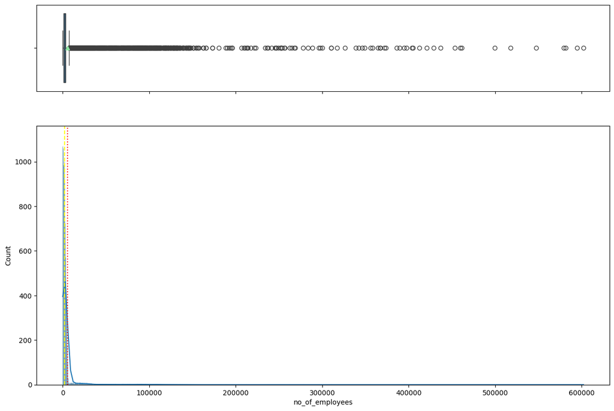

```python
histogram_boxplot(df,'no_of_employees')
```

Observations:

1. The distribution of the number of employees is extremly skewed to the right.
2. It can be implied that the dataset has small companies, medium companies, and large international companies.

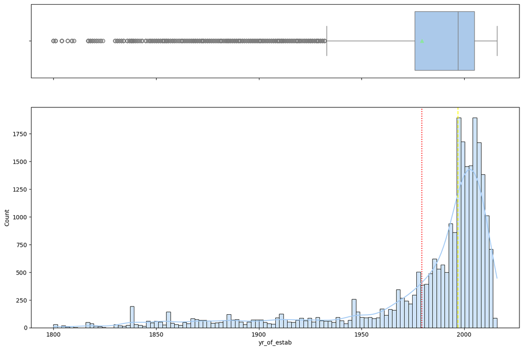

```python
histogram_boxplot(df,'yr_of_estab')
```

Observations:

1. The distribution of the year of establishment is extremly skewed to the left.
2. It can be implied that the dataset has more companies established in the late 1900s and early 2000s.

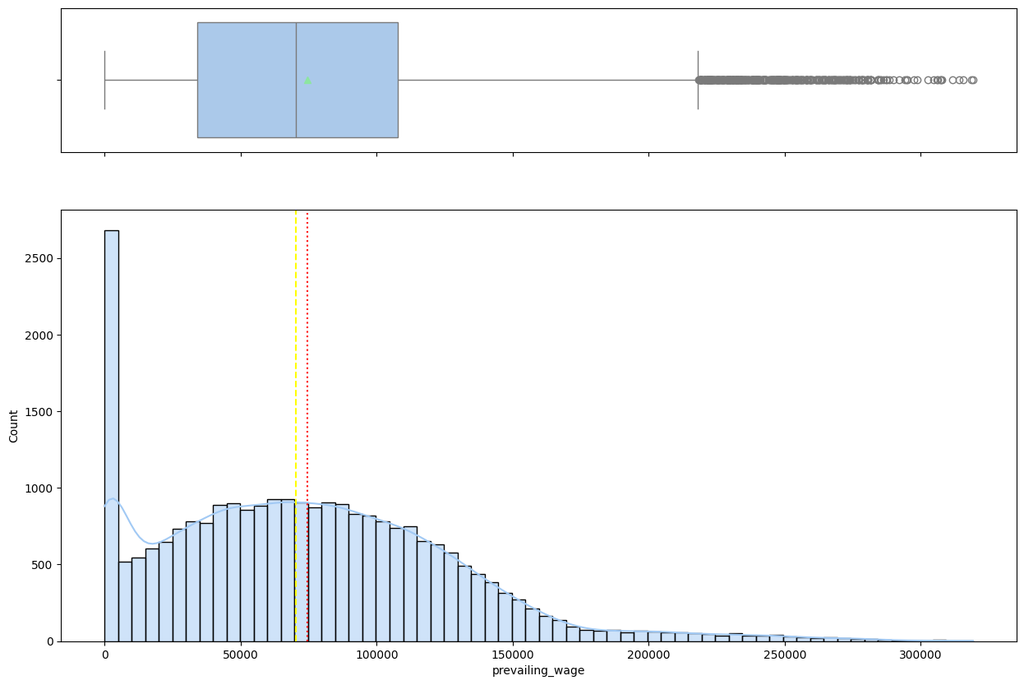

```python
histogram_boxplot(df,'prevailing_wage')
```

```python
df.loc[df['prevailing_wage']<100].head()
```

|  | continent | education_of_employee | has_job_experience | requires_job_training | no_of_employees | yr_of_estab | region_of_employment | prevailing_wage | unit_of_wage | full_time_position | case_status |
| --- | --- | --- | --- | --- | --- | --- | --- | --- | --- | --- | --- |
| 338 | Asia | Bachelor's | Y | N | 2114 | 2012 | Northeast | 15.7716 | Hour | Y | Certified |
| 634 | Asia | Master's | N | N | 834 | 1977 | Northeast | 3.3188 | Hour | Y | Denied |
| 839 | Asia | High School | Y | N | 4537 | 1999 | West | 61.1329 | Hour | Y | Denied |
| 876 | South America | Bachelor's | Y | N | 731 | 2004 | Northeast | 82.0029 | Hour | Y | Denied |
| 995 | Asia | Master's | N | N | 302 | 2000 | South | 47.4872 | Hour | Y | Certified |

Observations:

1. The distribution of the prevailing wage is skewed to the right.
2. There is a huge difference between wages among applicants.
3. Looks like small wages are hourly based.

```python
#Labelled bar plots for categorical columns

def labelled_barplot(data, feature):

    #count of occurences of each unique value in the feature
    count_data = data[feature].value_counts().reset_index()
    count_data.columns = ['Feature', 'Count']

    #Calculate the % of each count
    total_count = count_data['Count'].sum()
    count_data['Percentage'] = (count_data['Count'] / total_count) * 100

    #Create the bar plot
    plt.figure(figsize=(10, 6))
    sns.barplot(x='Feature', y='Count', data=count_data)

    #adding % on the bars
    for index, row in count_data.iterrows():
        plt.text(row.name, row.Count, f"{row.Percentage:.1f}%", color ='black', ha="center")


    plt.title(f"Distribution of {feature}")
    plt.xlabel(f"{feature}")
    plt.ylabel("count")
    plt.show()
```

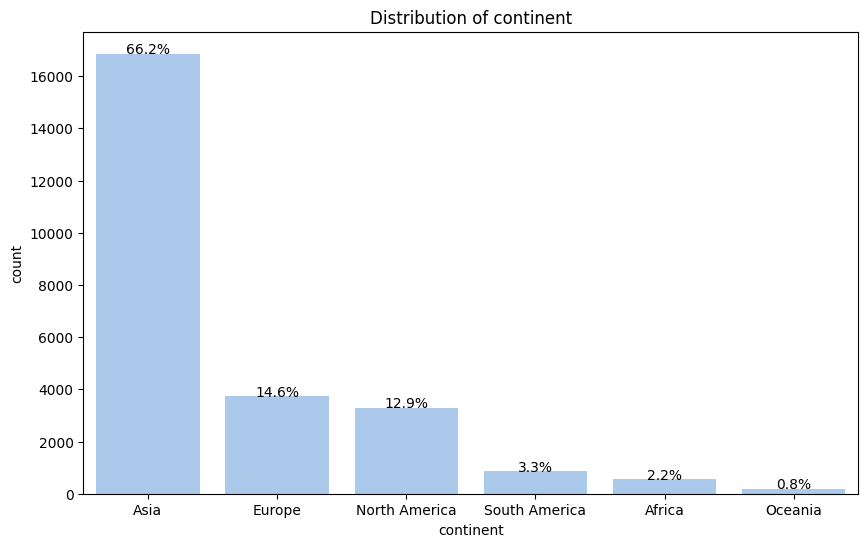

```python
labelled_barplot(df, "continent")
```

Observation :

66% are coming from Asia, 15% are coming from EU, and 13% are coming from North Amercia.

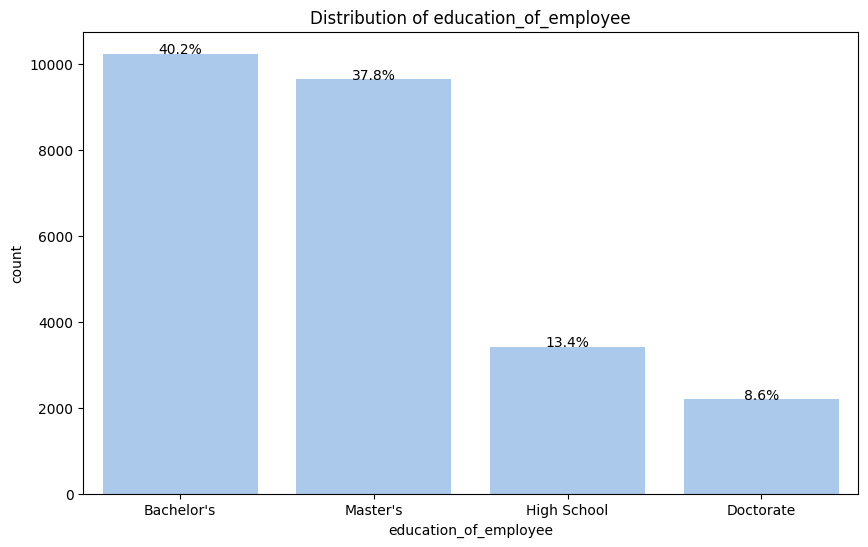

```python
labelled_barplot(df, "education_of_employee")
```

Observation :

1. 40.2% of the applicants have a bachelor's degree, followed by 37.8% having a master's degree.
2. 8.6% of the applicants have a doctorate degree.

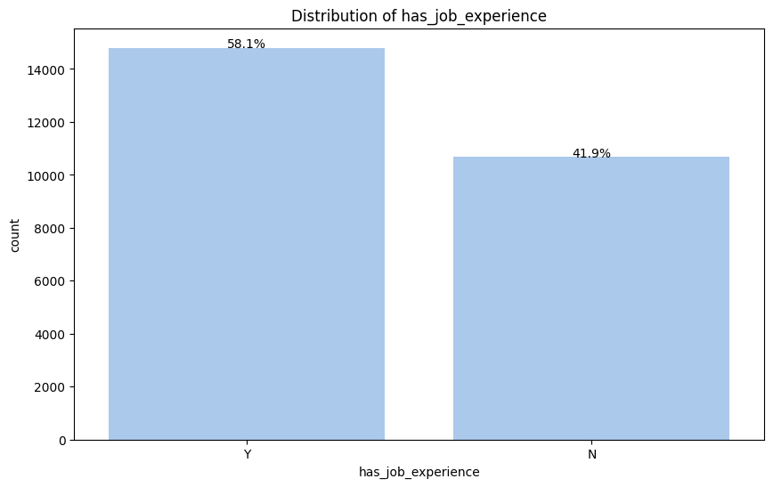

```python
labelled_barplot(df, "has_job_experience")
```

Observation:

More than half the employees have work experience.

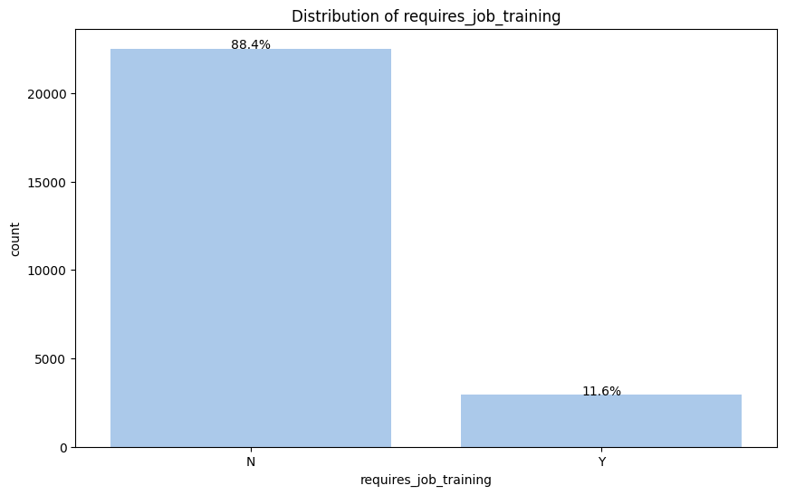

```python
labelled_barplot(df, "requires_job_training")
```

Observation:

Predominant share of the employees don't need any job training which means it's easier for them to onboard for a job.

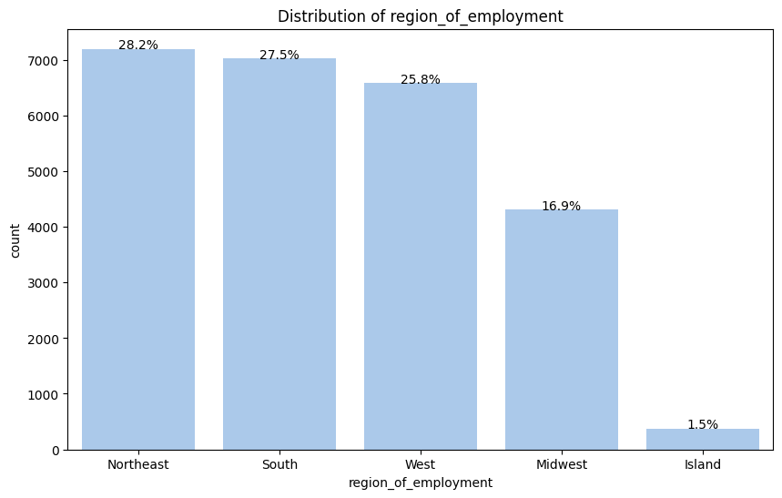

```python
labelled_barplot(df, "region_of_employment")
```

Observations :

1. Northeast, South, and West are equally distributed.
2. The Island regions have only 1.5% of the applicants looks like an outlier.

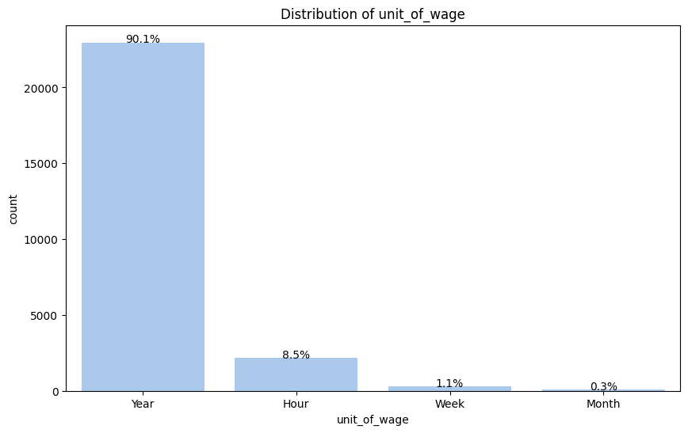

```python
labelled_barplot(df, "unit_of_wage")
```

Observation:

1. Yearly wage seems to be the most common form for employees.
2. Monthly wage is so less that it looks like an outlier.

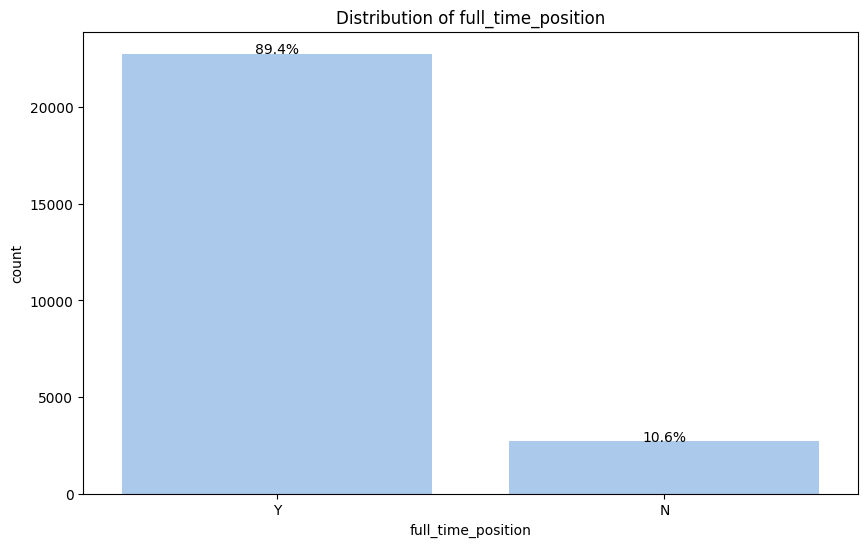

```python
labelled_barplot(df, "full_time_position")
```

Observations:

The data looks one sided where most of the employees have a full time position.

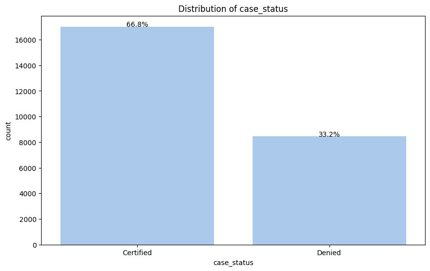

```python
labelled_barplot(df, "case_status")
```

Observations:

1. Looks like an unbalanced data.
2. Most of the applicants are granted visa.

#### Bivariate Analysis

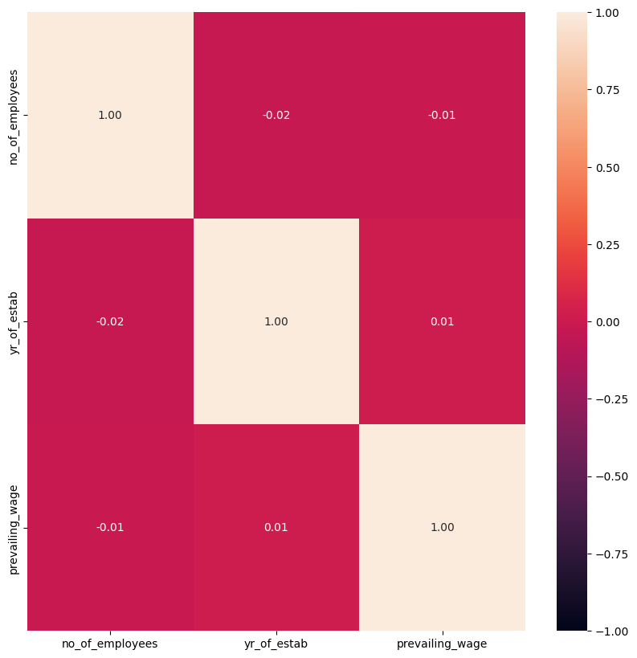

```python
# Heatmap to visualise the correlation of numerical variables
plt.figure(figsize=(10,10))
sns.heatmap(df.select_dtypes(include="number").corr(),vmax=1,vmin=-1,annot=True,fmt=".2f")
```

Observations:

There seems to be no correlation between numerical variables as all the values are close to zero.

```python
#distribution for comparing Numerical variables with target variable

def distribution_plot(data,x_var,target):
    fig, axes = plt.subplots(2,2,figsize=(12,10))
    target_var = data[target].unique()

    #Histogram with unique values of the target variable
    axes[0,0].set_title("distribution of target = "+ str(target_var[0]))
    sns.histplot(data=data[data[target] == target_var[0]],x = x_var,kde=True,ax=axes[0,0],stat='density')
    axes[0,1].set_title("distribution of target = "+ str(target_var[1]))
    sns.histplot(data=data[data[target] == target_var[1]],x = x_var,kde=True,ax=axes[0,1],stat='density')

    #Box plot with and without outliers
    axes[1,0].set_title("Box Plot with outliers")
    sns.boxplot(x=target, y=x_var, data=data, ax=axes[1,0])
    axes[1,1].set_title("Box Plot without outliers")
    sns.boxplot(x=target, y=x_var, data=data, ax=axes[1,1],showfliers=False)


    plt.tight_layout()
    plt.show()
```

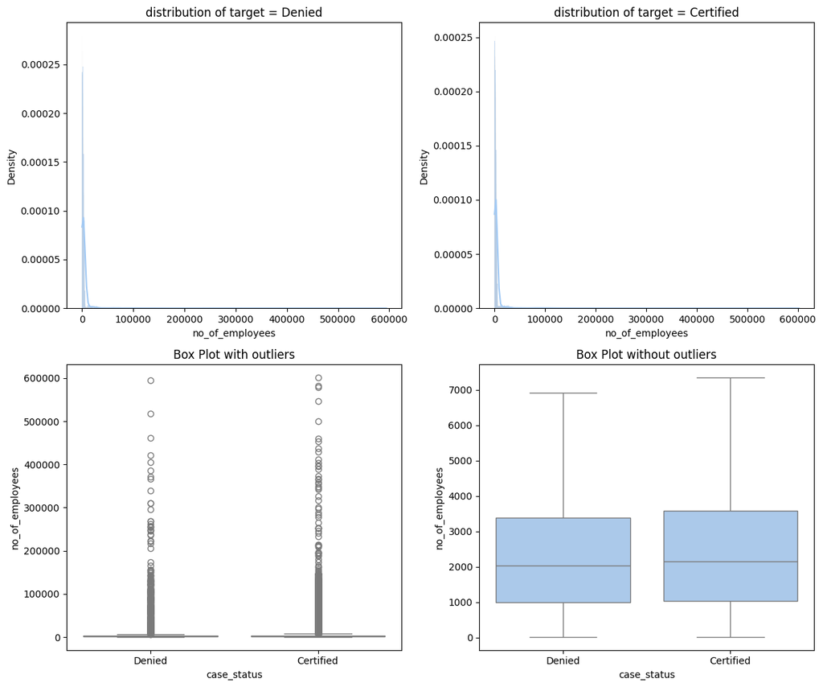

```python
distribution_plot(df,'no_of_employees','case_status')
```

Observations:

1. The median no of employees of the companies for both denied and certified employees is almost same.
2. Most of the companies have employees between ~ 1000-3000.

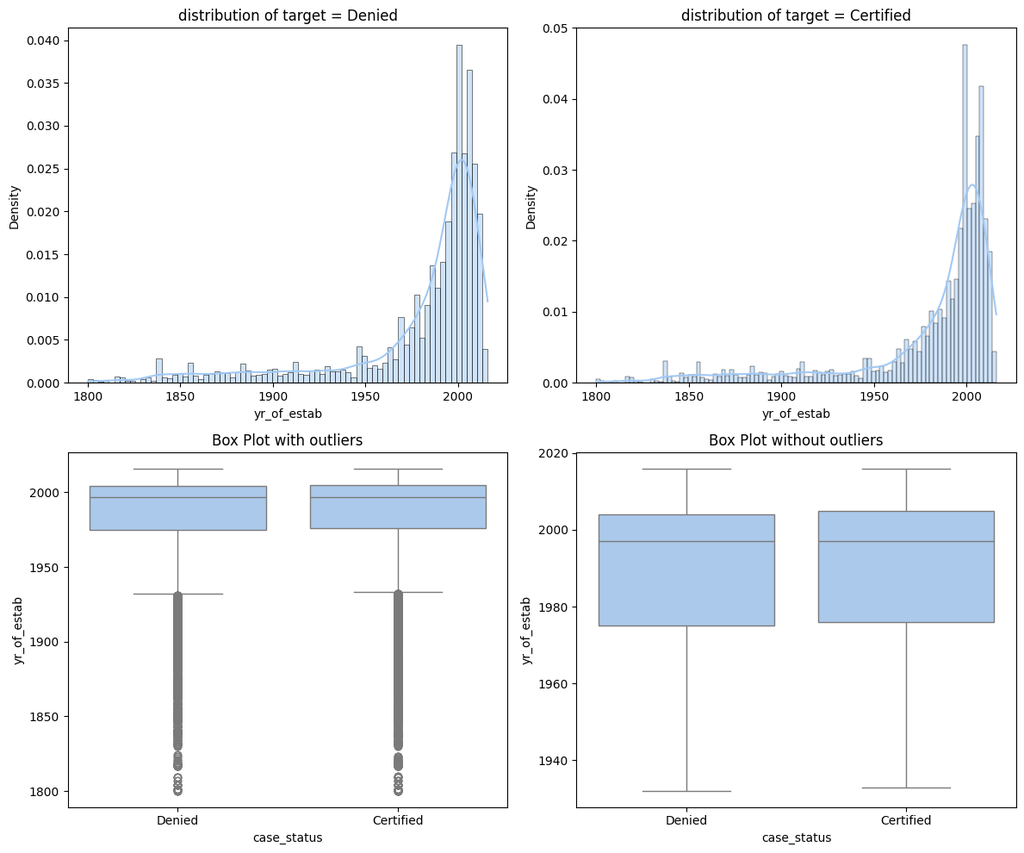

```python
distribution_plot(df,'yr_of_estab','case_status')
```

Observations:

1. The median year of establishment of the companies for both denied and certified employees is same.
2. Most of the companies were established between ~ 1970-2005.

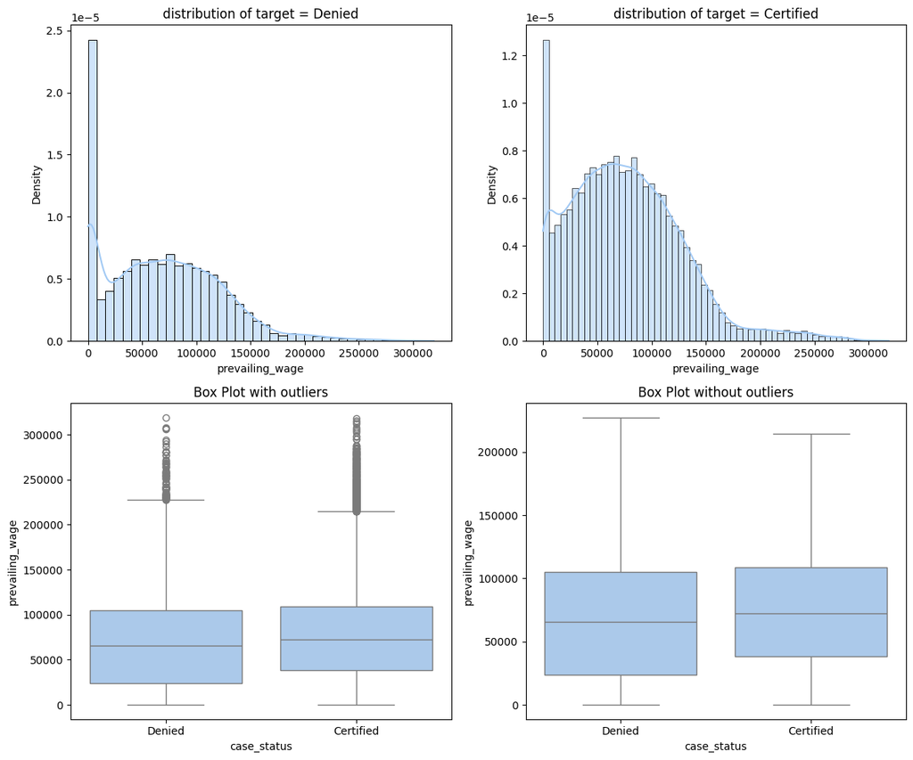

```python
distribution_plot(df,'prevailing_wage','case_status')
```

Observations:

1. 50% of the employees wages are between 25,000 - 1,00,000.
2. The median wage of certified applications is more than the denied applications.

```python
#Stacked bar chart for comparing Categorical variables with target Variable

def stacked_bar_plot(data,x_var,target):

    count=data[x_var].nunique()
    sorter=data[target].value_counts().index[-1]
    pd.crosstab(data[x_var],data[target],normalize='index').sort_values(by=sorter, ascending=False).plot(kind='bar', stacked=True, figsize=(10, 6))
```

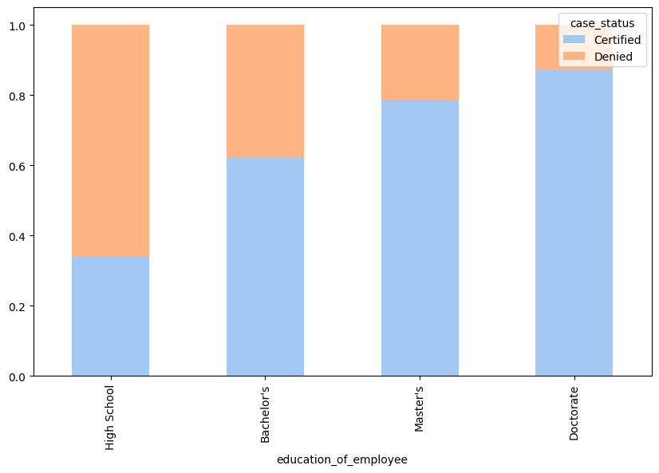

```python
stacked_bar_plot(df,"education_of_employee", "case_status")
```

Observation:

The higher the education, the more chance to get certified.

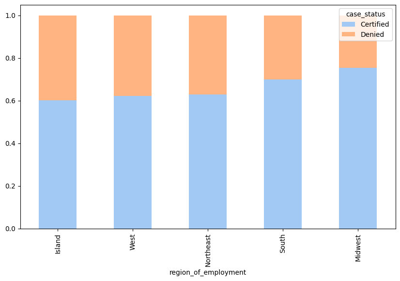

```python
stacked_bar_plot(df,"region_of_employment", "case_status")
```

Observation :

1. Midwest has the highest positive case chance.
2. Island, in the opposite side, has the lowest positive case chance.

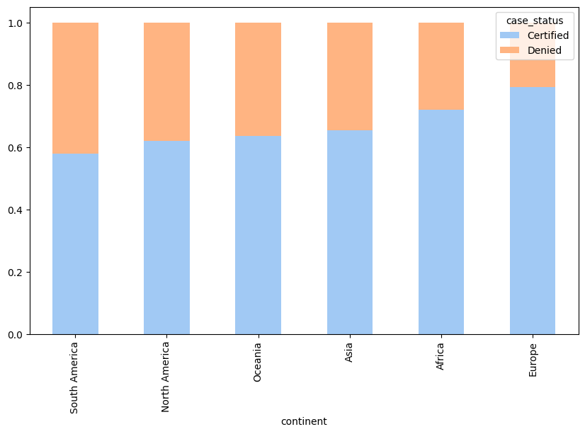

```python
stacked_bar_plot(df, "continent", "case_status")
```

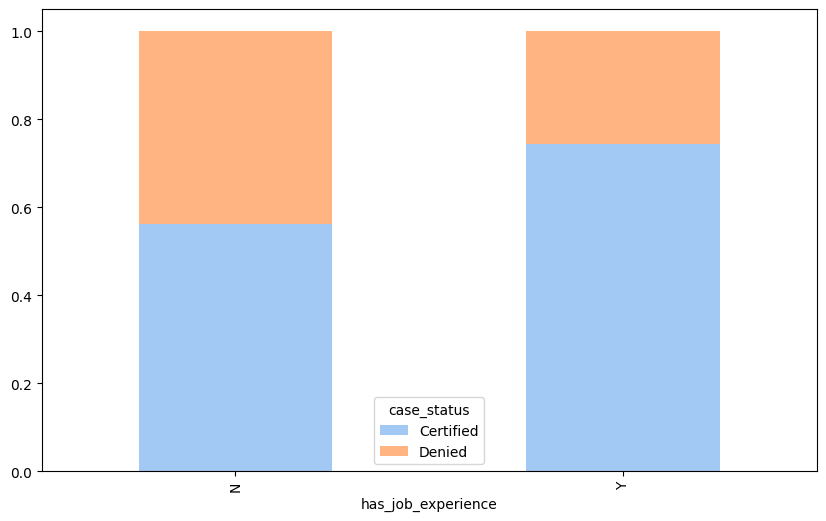

```python
stacked_bar_plot(df, "has_job_experience", "case_status")
```

Observations:

People who have job experience have higher chance of getting certified.

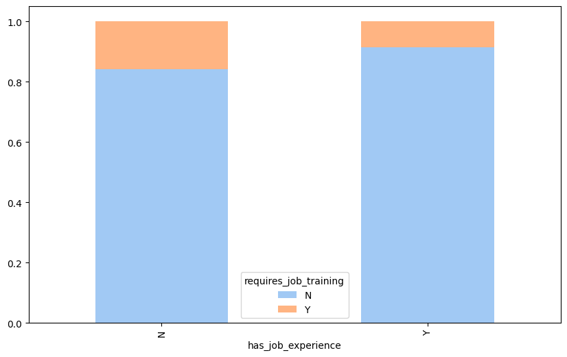

```python
stacked_bar_plot(df, "has_job_experience", "requires_job_training")
```

Observations:

If the applicant has a job experience, they are less likely to require training.

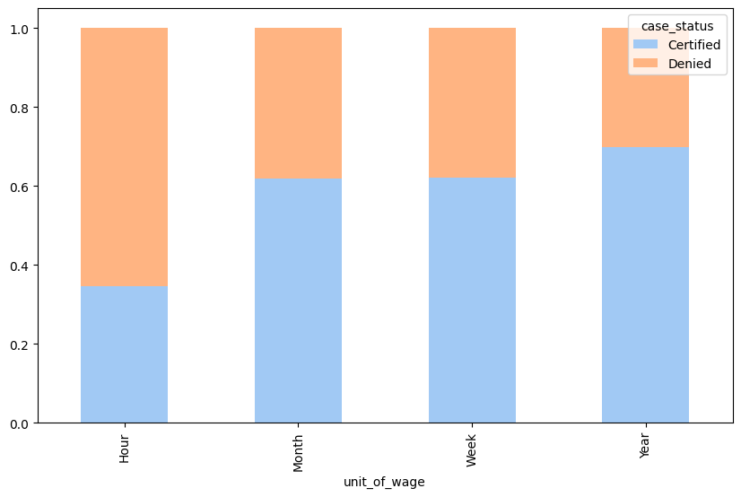

```python
stacked_bar_plot(df, "unit_of_wage", "case_status")
```

Observations:

Hourly waged applicants are more likely to get denied while yearly are more likley to get certified.

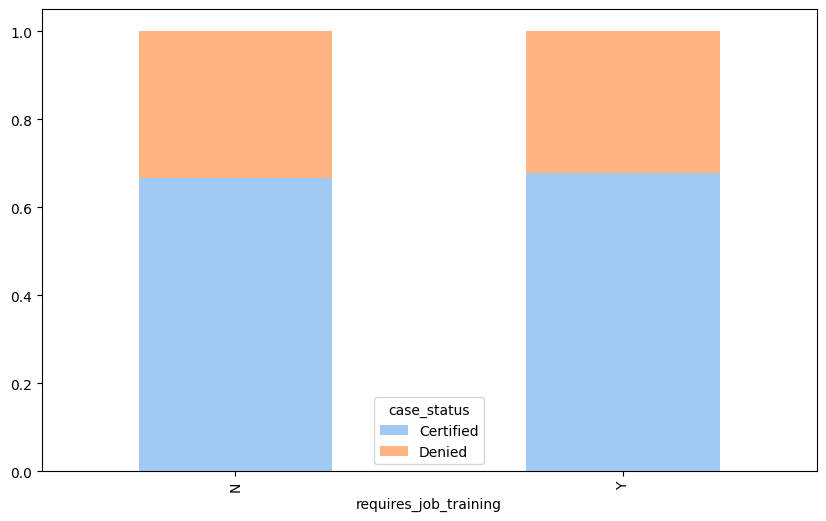

```python
stacked_bar_plot(df, "requires_job_training", "case_status")
```

Observations:

Irrespective of denied or certified applicants looks like they equally require job training.

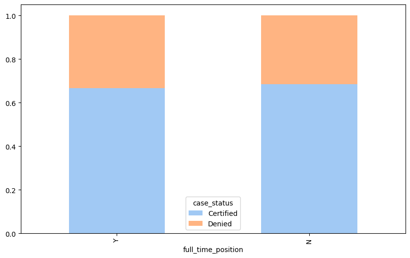

```python
stacked_bar_plot(df, "full_time_position", "case_status")
```

```python
#Outlier check

def outlier_check(data, column):
    plt.figure(figsize=(8,6))
    sns.boxplot(data=data[column])
    plt.xlabel(column)
    plt.title(f"Boxplot for {column}")
    plt.show()
```

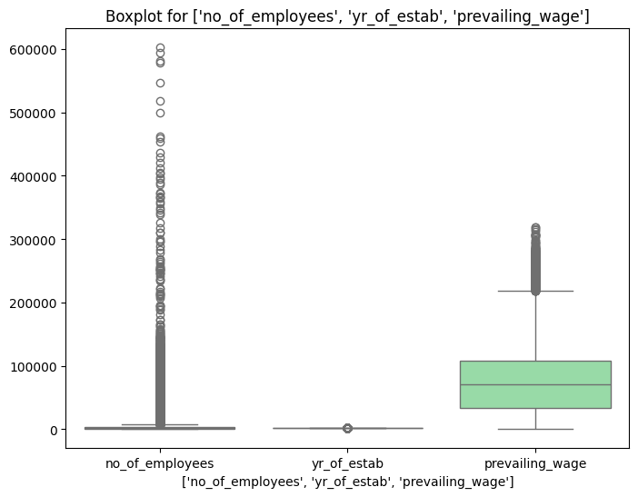

```python
#Plot the graphs

numerical_columns = df.select_dtypes(include=np.number).columns.tolist()
outlier_check(df, numerical_columns)
```

Observations:

Although there are outliers, we will keep them as they have a valuable input.

#### Data Preparation for Modelling

```python
#Convert the target column as binary

df['case_status'] = df['case_status'].apply(lambda x: 1 if x == "Certified" else 0)
df.head()
```

|  | continent | education_of_employee | has_job_experience | requires_job_training | no_of_employees | yr_of_estab | region_of_employment | prevailing_wage | unit_of_wage | full_time_position | case_status |
| --- | --- | --- | --- | --- | --- | --- | --- | --- | --- | --- | --- |
| 0 | Asia | High School | N | N | 14513 | 2007 | West | 592.2029 | Hour | Y | 0 |
| 1 | Asia | Master's | Y | N | 2412 | 2002 | Northeast | 83425.6500 | Year | Y | 1 |
| 2 | Asia | Bachelor's | N | Y | 44444 | 2008 | West | 122996.8600 | Year | Y | 0 |
| 3 | Asia | Bachelor's | N | N | 98 | 1897 | West | 83434.0300 | Year | Y | 0 |
| 4 | Africa | Master's | Y | N | 1082 | 2005 | South | 149907.3900 | Year | Y | 1 |

```python
#convert the object data type into category

categorical_columns = df.select_dtypes(include='object').columns.tolist()
df[categorical_columns] = df[categorical_columns].apply(lambda col: col.astype('category'))
df.info()
```

```
<class 'pandas.core.frame.DataFrame'>
RangeIndex: 25480 entries, 0 to 25479
Data columns (total 11 columns):
 #   Column                 Non-Null Count  Dtype
---  ------                 --------------  -----
 0   continent              25480 non-null  category
 1   education_of_employee  25480 non-null  category
 2   has_job_experience     25480 non-null  category
 3   requires_job_training  25480 non-null  category
 4   no_of_employees        25480 non-null  int64
 5   yr_of_estab            25480 non-null  int64
 6   region_of_employment   25480 non-null  category
 7   prevailing_wage        25480 non-null  float64
 8   unit_of_wage           25480 non-null  category
 9   full_time_position     25480 non-null  category
 10  case_status            25480 non-null  int64
dtypes: category(7), float64(1), int64(3)
memory usage: 971.7 KB
```

```python
#Drop the target variable
X = df.drop(["case_status"], axis = 1)
y = df["case_status"]

#create dummies
X = pd.get_dummies(X, drop_first=True)

#Create train and test split
X_train, X_test, y_train, y_test = train_test_split(X, y, test_size=0.3, random_state=1, stratify=y)
```

```python
#To check the class proportion and train and test data size

print(f'Shape of training data X_train shape is: {X_train.shape}')
print(f'Shape of testing data X_test shape is: {X_test.shape}')

print(f"Class Proportion in Training Set: {y_train.value_counts(normalize=True)}")
print(f"Class Proportion in Test Set: {y_test.value_counts(normalize=True)}")
```

```
Shape of training data X_train shape is: (17836, 21)
Shape of testing data X_test shape is: (7644, 21)
Class Proportion in Training Set: case_status
1    0.667919
0    0.332081
Name: proportion, dtype: float64
Class Proportion in Test Set: case_status
1    0.667844
0    0.332156
Name: proportion, dtype: float64
```

```python
#define a function to compute different metrics to check performance of a classification model

def model_performance(model, predictors, target):

    #predicting using the independant variables
    predictions = model.predict(predictors)

    #calculating the performance metrics
    accuracy = accuracy_score(target, predictions)
    recall = recall_score(target, predictions)
    precision = precision_score(target, predictions)
    f1 = f1_score(target, predictions)

    #creating a dataframe of metrics
    performance_metrics_df = pd.DataFrame({"Accuracy": accuracy, "Recall": recall, "Precision": precision, "F1": f1},index=[0])

    return performance_metrics_df
```

```python
# Compute the confusion matrix

def confmat(model, predictors, target):

    y_pred = model.predict(predictors)
    cm = confusion_matrix(target, y_pred)
    labels = np.asarray(
        [
            ["{0:0.0f}".format(item) + "\n{0:.2%}".format(item / cm.flatten().sum())]
            for item in cm.flatten()
        ]
    ).reshape(2, 2)

    plt.figure(figsize=(6, 4))
    sns.heatmap(cm, annot=labels, fmt="")
    plt.ylabel("True label")
    plt.xlabel("Predicted label")
```

```python
# Plot the feature importances graph for each model

def feature_imp_plot(model,X_train):
    feature_names = list(X_train.columns)
    importances = model.feature_importances_
    indices = np.argsort(importances)
    plt.figure(figsize=(15,15))
    plt.title('Feature Importances')
    plt.barh(range(len(indices)), importances[indices], color ="red", align="center")
    plt.yticks(range(len(indices)), [feature_names[i] for i in indices])
    plt.xlabel("Relative importance")
    plt.show()
```

```python
#Create Oversampled dataset

print("Before OS, shape of dataset : {}".format(X_train.shape, y_train.shape))
print("Before OS, Label certified : {}".format(sum(y_train==1)))
print("Before OS, Label denied : {}".format(sum(y_train==0)))

#use SMOTE to oversample the data - Synthetic minority oversampling
sm = SMOTE(sampling_strategy=1, k_neighbors = 5, random_state=1)
X_train_OS, y_train_OS = sm.fit_resample(X_train, y_train)

print("After OS, Label certified : {}".format(sum(y_train_OS==1)))
print("After OS, Label denied : {}".format(sum(y_train_OS==0)))
print("After OS, shape of dataset : {}".format(X_train_OS.shape, y_train_OS.shape))
```

```
Before OS, shape of dataset : (17836, 21)
Before OS, Label certified : 11913
Before OS, Label denied : 5923
After OS, Label certified : 11913
After OS, Label denied : 11913
After OS, shape of dataset : (23826, 21)
```

```python
#Create Undersampled dataset

print("Before US, shape of dataset : {}".format(X_train.shape, y_train.shape))
print("Before US, Label certified : {}".format(sum(y_train==1)))
print("Before US, Label denied : {}".format(sum(y_train==0)))

#use RandomUndersampler to undersample the data
rus = RandomUnderSampler(random_state=1)
X_train_US, y_train_US = rus.fit_resample(X_train, y_train)

print("After US, Label certified : {}".format(sum(y_train_US==1)))
print("After US, Label denied : {}".format(sum(y_train_US==0)))
print("After US, shape of dataset : {}".format(X_train_US.shape, y_train_US.shape))
```

```
Before US, shape of dataset : (17836, 21)
Before US, Label certified : 11913
Before US, Label denied : 5923
After US, Label certified : 5923
After US, Label denied : 5923
After US, shape of dataset : (11846, 21)
```

Model can make wrong predictions as:

1. Model predicts that the visa application will get certified but in reality, the visa application should get denied. (FP - Precision)
2. Model predicts that the visa application will not get certified but in reality, the visa application should get certified. (FN - Recall)

Which case is more important?

Both the cases are important as:

1. If a visa is certified when it had to be denied a wrong employee will get the job position while US citizens will miss the opportunity to work on that position.
2. If a visa is denied when it had to be certified the U.S. will lose a suitable human resource that can contribute to the economy.

How to reduce the losses?

**F1 Score** can be used a the metric for evaluation of the model, greater the F1 score higher are the chances of minimizing False Negatives and False Positives.

#### BAGGING

1. Model1 - Decision tree using original data
2. Model2 - Decision tree using oversampled data
3. Model3 - Decision tree using undersampled data
4. Model4 - Bagging Classifier using original data
5. Model5 - Bagging Classifier using oversampled data
6. Model6 - Bagging Classifier using undersampled data
7. Model7 - Random Forest using original data
8. Model8 - Random Forest using oversampled data
9. Model9 - Random Forest using undersampled data

Model 1 - Decision tree with original data

```python
#Train the Decision Tree on original data
model1 = DecisionTreeClassifier(random_state=1)
model1.fit(X_train, y_train)
```

```
DecisionTreeClassifier(random_state=1)
```

```python
#Get the training metrics
confmat(model1, X_train, y_train)
```

[output not shown]

```python
model1_train_df = model_performance(model1, X_train, y_train)
model1_train_df
```

|  | Accuracy | Recall | Precision | F1 |
| --- | --- | --- | --- | --- |
| 0 | 1.0 | 1.0 | 1.0 | 1.0 |

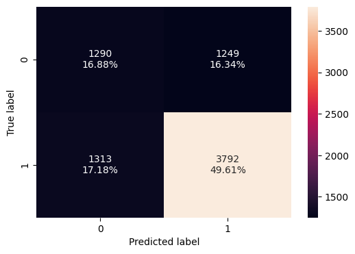

```python
##Get the testing metrics
confmat(model1, X_test, y_test)
```

```python
model1_test_df = model_performance(model1, X_test, y_test)
model1_test_df
```

|  | Accuracy | Recall | Precision | F1 |
| --- | --- | --- | --- | --- |
| 0 | 0.664835 | 0.742801 | 0.752232 | 0.747487 |

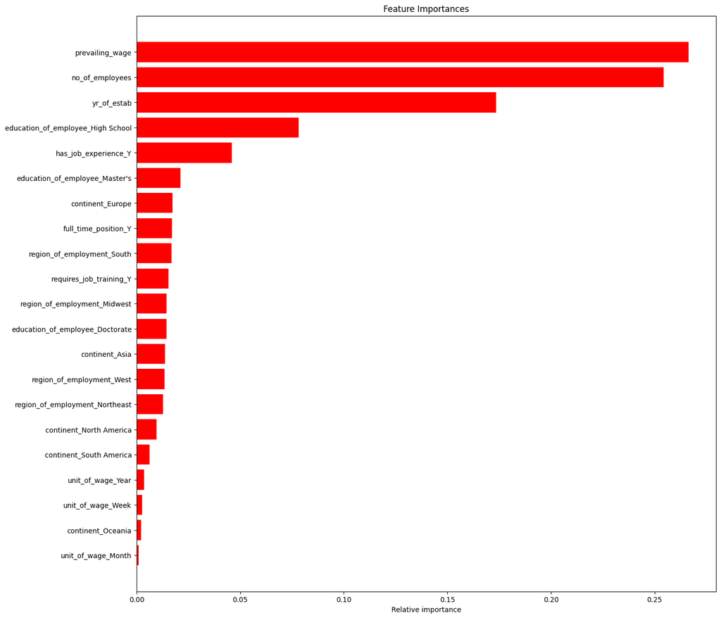

```python
feature_imp_plot(model1,X_train)
```

Model2 - Decision tree using oversampled data

```python
#Train the Decision Tree on oversampled data
model2 = DecisionTreeClassifier(random_state=1)
model2.fit(X_train_OS, y_train_OS)
```

```
DecisionTreeClassifier(random_state=1)
```

|  | Accuracy | Recall | Precision | F1 |
| --- | --- | --- | --- | --- |
| 0 | 1.0 | 1.0 | 1.0 | 1.0 |

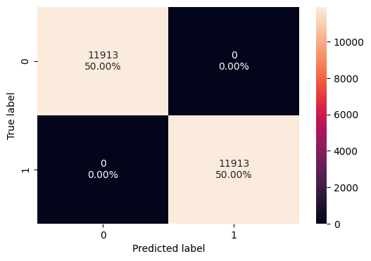

```python
#Get the training metrics
confmat(model2, X_train_OS, y_train_OS)

model2_train_df = model_performance(model2, X_train_OS, y_train_OS)
model2_train_df
```

|  | Accuracy | Recall | Precision | F1 |
| --- | --- | --- | --- | --- |
| 0 | 0.657248 | 0.722821 | 0.75383 | 0.738 |

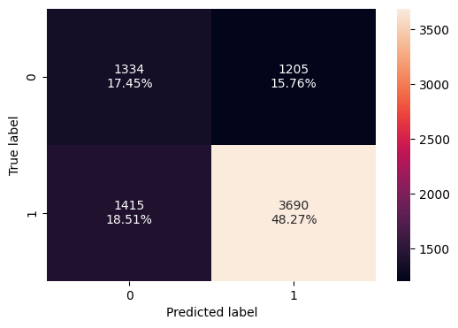

```python
#Get the testing metrics
confmat(model2, X_test, y_test)

model2_test_df = model_performance(model2, X_test, y_test)
model2_test_df
```

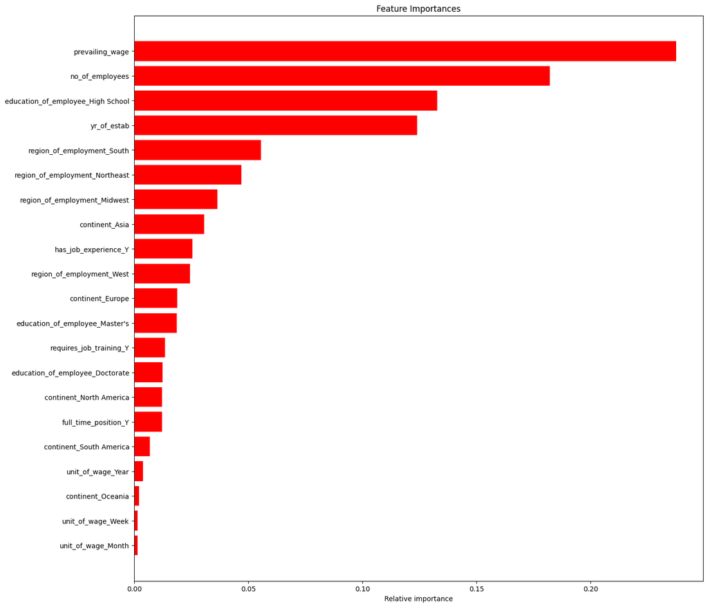

```python
feature_imp_plot(model2,X_train_OS)
```

Model3 - Decision tree using undersampled data

```python
#Train the Decision Tree on undersampled data
model3 = DecisionTreeClassifier(random_state=1)
model3.fit(X_train_US, y_train_US)
```

```
DecisionTreeClassifier(random_state=1)
```